# Stupidest sampler presentation

8 1 2023

## Before presenting

Hit Ctrl + Plus a couple of times, then F (full screen). Depending on the resolution of the projector, I may also need to press W.

## Bayesian statistics

## 01 The supidest sampler ever

## We have some coin tosses

```r
data<-c("heads","tails","heads","heads")
```

## Look at them

```r
data
```

```
## [1] "heads" "tails" "heads" "heads"
```

## How do we even begin to think about this?

The most straightforward way probably is to simulate both options, generate 4 coin tosses with each and see, how often each coin generates “heads”,“tails”,“heads”,“heads”.

### This is a fair coin

```r
sample(c("heads","tails"),size=4,prob=c(0.5,0.5),replace=T)
```

```
## [1] "heads" "heads" "tails" "heads"
```

### This is an unfair (trick) coin

```r
sample(c("heads","tails"),size=4,prob=c(0.8,0.2),replace=T)
```

```
## [1] "heads" "heads" "heads" "heads"
```

## One toss is not enough.

I will modify the code to do four coin tosses with each coin 1000 times.

```r
d.fair<-replicate(n=1000,sample(c("heads","tails"),size=4,prob=c(0.5,0.5),replace=T))
str(d.fair)
```

```
##  chr [1:4, 1:1000] "heads" "heads" "tails" "heads" "heads" "tails" "tails" ...
```

## I do not like this in “wide” format

with few rows and many columns (transpose)

```r
d.fair<-t(d.fair)
head(d.fair)
```

```
##      [,1]    [,2]    [,3]    [,4]
## [1,] "heads" "heads" "tails" "heads"
## [2,] "heads" "tails" "tails" "heads"
## [3,] "heads" "tails" "tails" "heads"
## [4,] "heads" "tails" "heads" "heads"
## [5,] "tails" "heads" "tails" "heads"
## [6,] "tails" "heads" "heads" "heads"
```

This is more like it!

## The equivalent for an unfair coin.

Notice that I put the output directly into the transpose function

```r
d.tric<-t(replicate(n=1000,sample(c("heads","tails"),size=4,prob=c(0.8,0.2),replace=T)))
head(d.tric)
```

```
##      [,1]    [,2]    [,3]    [,4]
## [1,] "heads" "tails" "heads" "heads"
## [2,] "heads" "heads" "heads" "heads"
## [3,] "heads" "tails" "heads" "heads"
## [4,] "heads" "heads" "heads" "heads"
## [5,] "heads" "heads" "heads" "heads"
## [6,] "heads" "heads" "tails" "tails"
```

## So ok.

How many cointoss sequences with each coin are exactly like mine

```r
pasted.data<-paste(data,collapse=" ")

pasted.fair<-apply(d.fair,1,paste,collapse=" ")
pasted.tric<-apply(d.tric,1,paste,collapse=" ")

str(pasted.fair)
```

```
##  chr [1:1000] "heads heads tails heads" "heads tails tails heads" ...
```

```r
str(pasted.tric)
```

```
##  chr [1:1000] "heads tails heads heads" "heads heads heads heads" ...
```

## How many are identical in each simulated set?

```r
pasted.data==pasted.fair
```

```
##    [1] FALSE FALSE FALSE  TRUE FALSE FALSE FALSE FALSE FALSE FALSE FALSE FALSE
##   [13] FALSE FALSE FALSE FALSE FALSE FALSE FALSE FALSE FALSE FALSE FALSE FALSE
##   [25] FALSE  TRUE  TRUE FALSE FALSE  TRUE FALSE FALSE  TRUE FALSE FALSE FALSE
##   [37]  TRUE FALSE FALSE FALSE FALSE FALSE FALSE FALSE FALSE FALSE FALSE  TRUE
##   [49] FALSE FALSE FALSE FALSE  TRUE FALSE FALSE FALSE FALSE FALSE FALSE FALSE
##   [61] FALSE FALSE FALSE FALSE FALSE FALSE FALSE FALSE FALSE FALSE FALSE FALSE
##   [73] FALSE FALSE FALSE FALSE FALSE FALSE FALSE FALSE FALSE FALSE FALSE FALSE
##   [85] FALSE FALSE FALSE FALSE FALSE FALSE FALSE  TRUE FALSE FALSE FALSE FALSE
##   [97] FALSE FALSE FALSE FALSE FALSE FALSE FALSE FALSE FALSE FALSE FALSE FALSE
##  [109] FALSE FALSE FALSE FALSE FALSE FALSE FALSE FALSE FALSE FALSE FALSE FALSE
##  [121] FALSE FALSE FALSE FALSE FALSE FALSE FALSE FALSE FALSE FALSE FALSE FALSE
##  [133] FALSE FALSE FALSE FALSE FALSE  TRUE FALSE FALSE FALSE FALSE FALSE FALSE
##  [145] FALSE FALSE FALSE FALSE FALSE FALSE FALSE  TRUE FALSE FALSE FALSE FALSE
##  [157] FALSE FALSE FALSE FALSE FALSE FALSE FALSE FALSE FALSE FALSE FALSE FALSE
##  [169] FALSE FALSE FALSE FALSE FALSE FALSE FALSE FALSE FALSE FALSE FALSE FALSE
```

[output cut: 69 more lines]

In total (remember, TRUE is 1, FALSE is 0)

```r
sum(pasted.data==pasted.fair)
```

```
## [1] 67
```

```r
sum(pasted.data==pasted.tric)
```

```
## [1] 103
```

## So what is the resulting probability?

From two hypotheses that I considered (that can be summarized as “heads falls with 50% probability” and “head falls with 80% probability”), I got

```r
match.fair<-sum(pasted.data==pasted.fair)
match.tric<-sum(pasted.data==pasted.tric)
match.fair+match.tric
```

```
## [1] 170
```

cases altogether

## This many

```r
match.fair
```

```
## [1] 67
```

of them were generated by the simulated fair coin

## This many

```r
match.tric
```

```
## [1] 103
```

## Learn from simulations

So my belief about how my original data were generated should change accordingly to these probabilities

```r
(simul.p1<-match.fair/(match.fair+match.tric))
```

```
## [1] 0.3941176
```

is the probability that is was the fair coin

```r
(simul.p2<-match.tric/(match.fair+match.tric))
```

```
## [1] 0.6058824
```

Divide so the probabilities of the considered hypotheses always add up to 1 (it must have been one of the considered coins).

## Going more abstract

We need to make our system simple and similar to other systems, so we treat each heads as TRUE (or 1) and each tails as FALSE (or 0)

```r
data<-data=="heads"
data
```

```
## [1]  TRUE FALSE  TRUE  TRUE
```

## We can now compute

not simulate - the probability of data such as ours with the two possible coins.

With the tric coin, the probability of TRUE (heads) is p=0.8, and the probability of FALSE (tails) is (1-p)=0.2.

Focus on the understanding of why probabilities of two events in the row are a result of multiplication of their probabilities. (Draw forking paths)

## Two cointosses

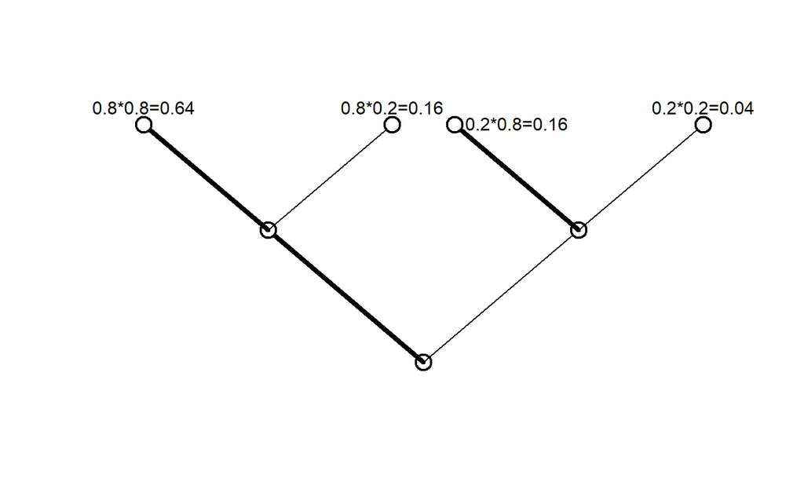

## It is easy, right?

So the probability of **TRUE FALSE TRUE TRUE** with coin characterized by a parameter of heads probability **p=0.8** is

```r
(calcul.l2<-0.8*0.2*0.8*0.8)
```

```
## [1] 0.1024
```

And the probability of the same data with the fair coin is

```r
(calcul.l1<-0.5*0.5*0.5*0.5)
```

```
## [1] 0.0625
```

## L for likelihood

What I am calculating could have been written like this: \[\text{likelihood of data if hypothesis} = P(d|H)\]

## Divide by sum,

Because it must have been one of the two, there are no other options.

```r
calcul.p1<-calcul.l1/(calcul.l1+calcul.l2)
calcul.p2<-calcul.l2/(calcul.l1+calcul.l2)
```

```
## [1] 0.3790176
```

```
## [1] 0.6209824
```

Notice how similar it is to the procedure that gave me

```r
simul.p1 #and
```

```
## [1] 0.3941176
```

```r
simul.p2
```

```
## [1] 0.6058824
```

## Always divide by the sum of all the equivalent alternatives.

The procedure that we demonstrate above is already very close to the very intuitive thing that is for some reason labeled “Bayes’ theorem”.

## Now we are at simple

“probability that a hypothesis is correct is proportional to the likelihood that given hypothesis generated data that we observe”.

\[P(H|d) = \frac{P(d|H)}{P(d)}\]

## What is this \(P(d)\)?

You can read it as “Probability of data regardless of the hypothesis”. How do we achieve this “regardless of hypothesis”? You have seen it twice already. You just sum up data likelihood over all the hypothesis that you even consider.

## Remember, in our worlds, we never observe hypotheses. We always observe only data.

## General models tend to be better

Before we bring it home, let us thing for a moment about the level of generality that we aim for in our analyses. There is no right or wrong here, but more general models are usually more useful and the statistics done on them is usually (when we scale to really big ones) way quicker.

## Answer this for yourself

Are we really concerned in what order did the heads or tails fell? Is the data relevant for us really “heads tails heads heads” or is it “three heads out of four”?

## If we just sum the data

We get the number of heads. We get to the level of abstraction on which we will from now on treat data like this.

```r
sum(data)
```

```
## [1] 3
```

So we got to a more abstract level - our data now basically say “3 out of 4 came out TRUE”

## Best book of statistics is Wikipedia

It is perfect that such a simple scenario has a very straigtforward analytical properties. https://en.wikipedia.org/wiki/Binomial_distribution Watch for PMF, whcih stands for Probability Mass Function.

## Combination number in R

```r
choose(5,2)
```

```
## [1] 10
```

## 3 scenarios

```r
choose(2,2) #2 heads out of two
choose(2,0) #0 heads, all tails
choose(2,1) #1 of each
```

```
## [1] 1
```

```
## [1] 1
```

```
## [1] 2
```

We can get back to our plot that tossed two unfair coins in a row.